# BC annual climate report for 2024

Author

Affiliation

Aseem Sharma e-mail: aseem.sharma@gov.bc.ca

Future Forest Ecosystems Centre, FCCSB, OCF, BC Ministry of Forests

Published

February 27, 2025

This report summarizes British Columbia (BC)’s climate conditions in 2024 based on three key variables: average temperature, total precipitation, and soil moisture drived from [ERA5-Land hourly dataset](https://cds.climate.copernicus.eu/cdsapp#!/dataset/reanalysis-era5-land?tab=overview).

# BC temperature in 2024

In 2024, the average annual temperature in BC increased by 0.96°C, ranking it as the 8<sup>th</sup> warmest year on record since 1950 (Figure 1). Globally, 2024 was the warmest year ever recorded[^1]; however, in BC, the warmest year remains 2023, which saw an average temperature increase of 2.15°C. Notably, seven of the 10 warmest years in BC have occurred since 2010 (Table 1) .

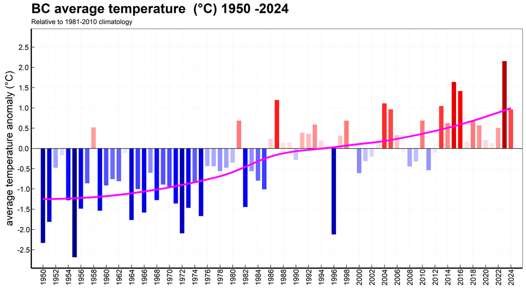

Figure 1: Annual average air temperature anomalies for BC 1950 - 2024. The bluish bars represent cooler-than-normal years, while the reddish bars indicate warmer-than-normal years. Anomalies are calculated relative to the 1981–2010 climatological baseline. The magenta line represents the moving regression. Data credit: *ERA5land/C3S/ECMWF*

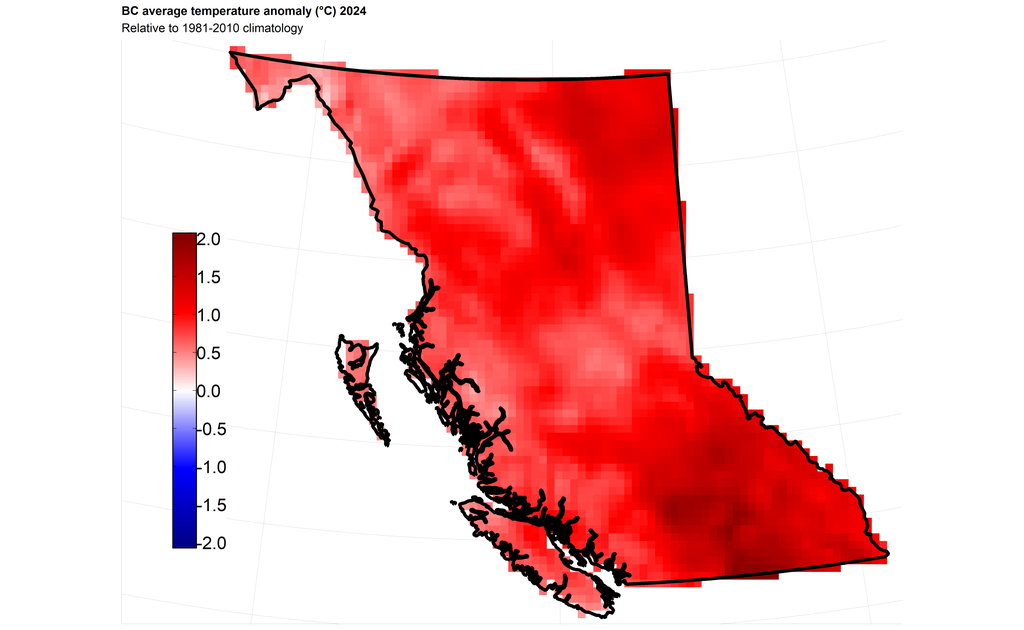

Figure 2: BC’s average air temperature anomaly for 2024 relative to the 1981–2010 reference period. The bluish areas represent cooler-than-normal temperatures, while the reddish areas indicate warmer-than-normal temperatures for 2024. *Data credit: ERA5land/C3S/ECMWF*

Table 1: Mean air temperature change and ranking relative to the 1981-2010 average for the top 15 warmest years between 1950 and 2024 in BC.Data credit: *ERA5land/C3S/ECMWF*

| Year | Rank | Warming (°C) |
| --- | --- | --- |
| 2023 | 1 | 2.15 |
| 2015 | 2 | 1.64 |
| 2016 | 3 | 1.41 |
| 1987 | 4 | 1.19 |
| 2004 | 5 | 1.11 |
| 2013 | 6 | 1.05 |
| 2005 | 7 | 0.96 |
| 2024 | 8 | 0.96 |
| 2018 | 9 | 0.69 |
| 2010 | 10 | 0.69 |
| 1998 | 11 | 0.69 |
| 1981 | 12 | 0.68 |
| 2014 | 13 | 0.62 |
| 1993 | 14 | 0.59 |
| 2019 | 15 | 0.57 |

[figure not shown]

Figure 3: Monthly average air temperature anomalies for BC in 2024. The bluish areas represent months with cooler-than-normal temperatures, while the reddish areas indicate months with warmer-than-normal temperatures.Data credit: *ERA5land/C3S/ECMWF*

# BC precipitation in 2024

Overall, precipitation amount in BC was slightly lower the normal (-2.73% anomaly) in 2024 relative to the 1981-2010 climatological average. This marks a continuation of the declining total precipitation observed since 2022 (Figure 4). However, there was considerable spatial variability across the province. Northeastern BC experienced a reduction in precipitation exceeding 30%, while the Central Interior recorded increases of up to 25% (Figure 5).

Seasonally, the year began with below-normal precipitation in January (4% decrease), February (14% decrease), and March (41% decrease). Although May and June were wetter then normal, drier-than-average conditions continue again in July (21% decrease) and August (15% decrease) however with notable spatial variability (Figure 6).

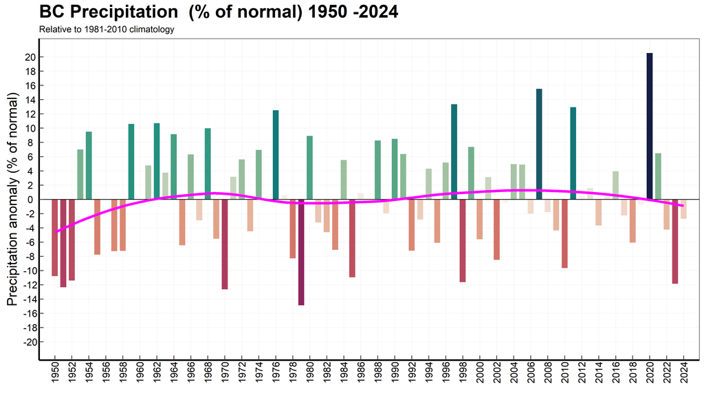

Figure 4: Annual precipitation anomalies ( % of normal) for BC 1950 - 2024. The greenish bars represent wetter-than-normal years, while the brownish bars indicate drier-than-normal years. Anomalies are calculated relative to the 1981–2010 climatological baseline. The magenta line represents the moving regression. Data credit: *ERA5land/C3S/ECMWF*

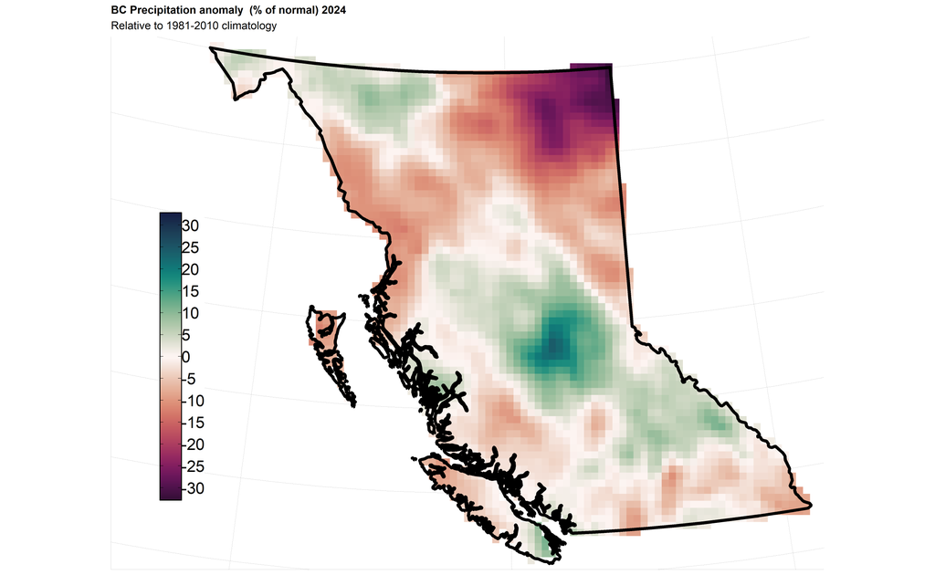

Figure 5: BC’s average precipitation anomaly for 2024 relative to the 1981–2010 reference period. The greenish areas represent wetter-than-normal precipitation areas, while the brownish areas indicate drier-than-normal precipitation for 2024. Data credit: *ERA5land/C3S/ECMWF*

[figure not shown]

Figure 6: Monthly total precipitation anomalies (% of normal) for BC in 2024. The greenish areas represent wetter-than-normal precipitation areas, while the brownish areas indicate drier-than-normal precipitation regions.Data credit: *ERA5land/C3S/ECMWF*

# Soil moisture and drought in 2024

Volumetric soil moisture is an important indicator of water availability for plant uptake, groundwater recharge, drought, and other hydrological processes. While the average annual soil moisture in 2024 was close to normal (-0.58%) (Figure 7),there were significant spatial and monthly variations across BC (Figure 8). In Northeast BC and the Peace Region, soil moisture remained below normal throughout the year, with levels over 30% lower than normal during the summer and fall months (Figure 9). July, August, and September experienced, on average, 7% ,6%, and 4% lower than normal soil moisture content respectively making drier months even more dry under the surface (Figure 9). This further restricted water availability for vegetation and crops during the growing season.

The drought conditions from 2023 continued into 2024, with lower-than-normal precipitation (Figure 6) and below normal snowpacks for most of the province during the winter months ( see [River Forecast Center’s](https://www2.gov.bc.ca/gov/content/environment/air-land-water/water/drought-flooding-dikes-dams/river-forecast-centre) Snow Survey and Water Supply Bulletins [report of 2024](https://www2.gov.bc.ca/assets/gov/environment/air-land-water/water/river-forecast/2024.pdf) ).

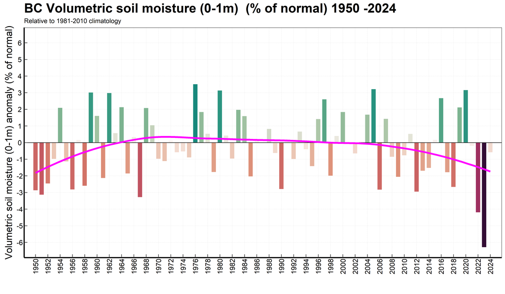

Figure 7: Annual volumetric soil moisture ( 0-1 m) anomalies ( % of normal) for BC 1950 - 2024. The greenish bars represent wetter-than-normal years, while the brownish bars indicate drier-than-normal years. Anomalies are calculated relative to the 1981–2010 climatological baseline. The magenta line represents the moving regression. Data credit: *ERA5land/C3S/ECMWF*

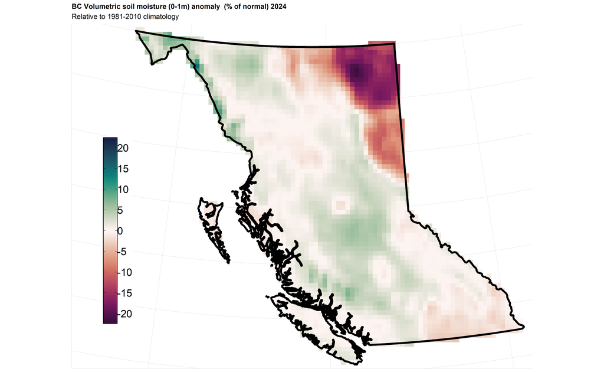

Figure 8: BC’s average volumetric soil moisture anomaly for 2024 relative to the 1981–2010 reference period. The greenish areas represent wetter-than-normal mositure areas, while the brownish areas indicate drier-than-normal mositure areas for 2024. Data credit: *ERA5land/C3S/ECMWF*

[figure not shown]

Figure 9: Monthly volumnetric soil mositure (0-1 m depth) anomalies (% of normal) for BC in 2024. The greenish areas represent wetter-than-normal soil mositure areas, while the brownish areas indicate drier-than-normal soil mositure conditions.Data credit: *ERA5land/C3S/ECMWF*

# Factors influcing warming and precipitation of BC in 2024

Globally the increase of the greenhouse gases concentration in the atmosphere due to fossil fuel combustion by humans is driving long-term warming. However, natural factors such as the El Niño phase of the El Niño-Southern Oscillation (ENSO), a naturally occurring periodic warming and cooling of ocean waters in the eastern and central tropical Pacific, as well as large volcanic eruptions and the solar cycle play a role in influencing short-term global and regional temperatures. The year 2024 continued with the warming phase of ENSO (El Niño) since 2023 until spring of 2024. During El Niño BC typically experiences warmer temperature therefore less precipitation as snowfall. Moreover, some reports suggest the role of Hunga Tonga volcanic eruption and reduction in marine fuel pollution to atmosphere also contributed to global temperature increase especially for past few years [^2].

**Data issues and Disclaimer:** This report has been prepared using [ERA5-Land](https://www.ecmwf.int/en/era5-land) data from the European Centre for Medium-Range Weather Forecasts (ECMWF), as available at the time of preparation. Please note that the original data may be subject to updates or revisions. Any modifications to the original data may result in adjustments to the findings presented in this report. There may be known or unknown issues with the data. For example, the ERA5-Land summertime time series for the year 1979 is affected by inhomogeneity. Users should acknowledge these limitations when using this report.

## Footnotes

[^1]: Tollefson, J. Earth shattered heat records in 2023 and 2024: is global warming speeding up? Nature 637, 523–524 (2025).
[^2]: [Berkeleyearth Global Temperature Report 2024](https://berkeleyearth.org/global-temperature-report-for-2024/)